# K-fold Factor Analysis - Lebenon Students

June 18, 2021

# Fold and Sample Summary

**# of folds:** 10

**# of variables:** 21

**# of observations:** 8027

**Maximum # of factors:**

- Allowed - 5
- Extracted - 5

# Model Summary

**Fit across folds by factor model**

[output not shown]

**Count of folds out of 10 with flagged problems**

| model | common structure | improper solution | heywood item | low loading | high factor correlation | low scale reliability |
| --- | --- | --- | --- | --- | --- | --- |
| 1-factor | 10 | 0 | 0 | 10 |  | 0 |
| 2-factor | 10 | 0 | 0 | 10 | 0 | 4 |
| 4-factor | 7 | 0 | 0 | 9 | 2 | 4 |
| 5-factor | 10 | 0 | 0 | 9 | 1 | 6 |
| Custom 2f |  | 0 | 0 | 9 | 8 | 0 |
| Break |  | 10 | 0 | 6 | 10 | 10 |

*Notes:*  
‘common structure’ is the number of folds the EFA identified the most common structure. Thus, “common structure” will be 10 when the same structure was identified in every fold and < 10 when multiple factor structures were identified. The most common structure was used in the CFA. See Appendix for all structures.  
‘improper solution’ is the number of folds with non-convergence or a non-positive definite matrix.  
‘high factor correlation’ threshold set to 0.9.  
‘low scale reliability’ threshold set to 0.6 with $\omega_h$.  
‘low loading’ threshold set to 0.3.  
blanks = not applicable

# Model Details

## 1-factor

**Factor Structure**

f1 =~ a1101x + a1102x + a1103x + a1104x + a1105x + a1106x + a1107x + a1108x + a1109x + a1110x + a1111x + a1112x + a1113x + a1114x + a1115x + a1116x + a1117x + a1118x + a1119x + a1120x + a1121x

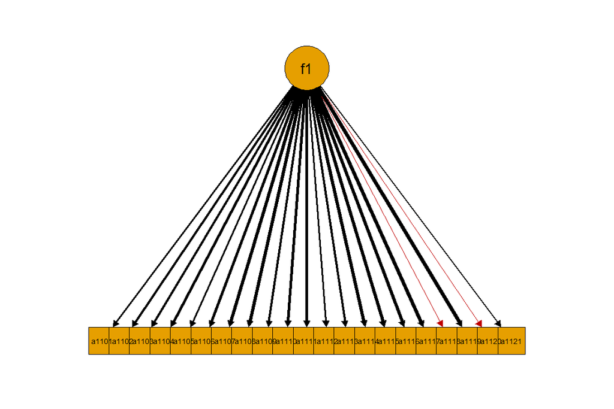

**Standardized Loading Across Folds**

| variable | mean | range | loading flag | heywood flag |
| --- | --- | --- | --- | --- |
| a1101x | 0.23 | 0.19 - 0.30 | 10 | 0 |
| a1102x | 0.54 | 0.45 - 0.60 | 0 | 0 |
| a1103x | 0.71 | 0.64 - 0.78 | 0 | 0 |
| a1104x | 0.50 | 0.44 - 0.55 | 0 | 0 |
| a1105x | 0.50 | 0.44 - 0.58 | 0 | 0 |
| a1106x | 0.59 | 0.55 - 0.64 | 0 | 0 |
| a1107x | 0.78 | 0.75 - 0.85 | 0 | 0 |
| a1108x | 0.66 | 0.60 - 0.72 | 0 | 0 |
| a1109x | 0.59 | 0.54 - 0.65 | 0 | 0 |
| a1110x | 0.82 | 0.71 - 0.89 | 0 | 0 |
| a1111x | 0.68 | 0.55 - 0.76 | 0 | 0 |
| a1112x | 0.62 | 0.54 - 0.71 | 0 | 0 |
| a1113x | 0.66 | 0.58 - 0.72 | 0 | 0 |
| a1114x | 0.73 | 0.66 - 0.78 | 0 | 0 |
| a1115x | 0.97 | 0.88 - 1.08 | 0 | 0 |
| a1116x | 0.93 | 0.88 - 1.02 | 0 | 0 |
| a1117x | 1.01 | 0.95 - 1.09 | 0 | 0 |
| a1118x | 0.32 | 0.21 - 0.43 | 4 | 0 |
| a1119x | 0.91 | 0.81 - 0.97 | 0 | 0 |
| a1120x | 0.33 | 0.17 - 0.38 | 2 | 0 |
| a1121x | 0.49 | 0.36 - 0.58 | 0 | 0 |

Note: loadings flagged when < 0.3 in a fold. ‘heywood flag’ is the number of folds the variable’s estimated residual variance was negative

**Scale Reliability Across Folds**

| factor | omega_h mean | omega_h range | omega_h flag | alpha mean | alpha range | alpha flag |
| --- | --- | --- | --- | --- | --- | --- |
| f1 | 0.88 | 0.87 - 0.89 | 0 | 0.90 | 0.89 - 0.90 | 0 |

Note: ‘flag’ is the number of folds the scale had a reliability < 0.6

## 2-factor

**Factor Structure**

f1 =~ a1101x + a1102x + a1103x + a1104x + a1105x + a1106x + a1107x + a1108x + a1109x + a1110x + a1111x + a1112x + a1113x + a1114x + a1115x + a1116x + a1117x + a1119x

f2 =~ a1118x + a1120x + a1121x

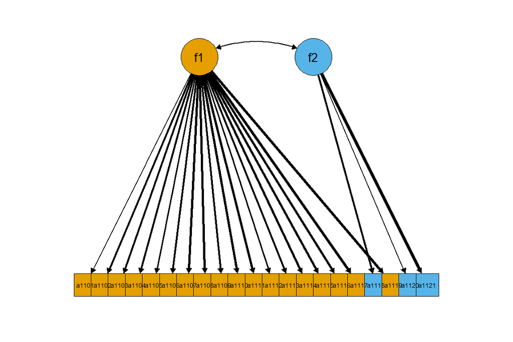

**Standardized Loading Across Folds**

| variable | mean | range | loading flag | heywood flag |
| --- | --- | --- | --- | --- |
| a1101x | 0.23 | 0.19 - 0.29 | 10 | 0 |
| a1102x | 0.54 | 0.45 - 0.60 | 0 | 0 |
| a1103x | 0.71 | 0.64 - 0.77 | 0 | 0 |
| a1104x | 0.50 | 0.44 - 0.56 | 0 | 0 |
| a1105x | 0.50 | 0.44 - 0.59 | 0 | 0 |
| a1106x | 0.59 | 0.55 - 0.64 | 0 | 0 |
| a1107x | 0.78 | 0.75 - 0.85 | 0 | 0 |
| a1108x | 0.66 | 0.61 - 0.72 | 0 | 0 |
| a1109x | 0.59 | 0.54 - 0.65 | 0 | 0 |
| a1110x | 0.82 | 0.71 - 0.89 | 0 | 0 |
| a1111x | 0.68 | 0.56 - 0.76 | 0 | 0 |
| a1112x | 0.62 | 0.54 - 0.70 | 0 | 0 |
| a1113x | 0.66 | 0.58 - 0.72 | 0 | 0 |
| a1114x | 0.74 | 0.67 - 0.79 | 0 | 0 |
| a1115x | 0.97 | 0.89 - 1.08 | 0 | 0 |
| a1116x | 0.93 | 0.88 - 1.02 | 0 | 0 |
| a1117x | 1.02 | 0.96 - 1.10 | 0 | 0 |
| a1118x | 0.71 | 0.59 - 0.83 | 0 | 0 |
| a1119x | 0.92 | 0.83 - 0.98 | 0 | 0 |
| a1120x | 0.70 | 0.52 - 0.86 | 0 | 0 |
| a1121x | 0.94 | 0.74 - 1.02 | 0 | 0 |

Note: loadings flagged when < 0.3 in a fold. ‘heywood flag’ is the number of folds the variable’s estimated residual variance was negative

**Mean Factor Correlations**

|  | f1 | f2 | flag |
| --- | --- | --- | --- |
| f1 | 1.00 |  | 0 |
| f2 | 0.46 | 1.00 | 0 |

Note: ‘flag’ is the number of folds the factor had a correlation > 0.9

**Scale Reliability Across Folds**

| factor | omega_h mean | omega_h range | omega_h flag | alpha mean | alpha range | alpha flag |
| --- | --- | --- | --- | --- | --- | --- |
| f1 | 0.90 | 0.89 - 0.91 | 0 | 0.90 | 0.89 - 0.91 | 0 |
| f2 | 0.62 | 0.58 - 0.67 | 4 | 0.62 | 0.58 - 0.66 | 4 |

Note: ‘flag’ is the number of folds the scale had a reliability < 0.6

## 4-factor

**Factor Structure**

f1 =~ a1101x + a1102x + a1103x + a1104x + a1105x + a1106x + a1107x + a1108x + a1109x

f2 =~ a1114x + a1115x + a1116x + a1117x + a1119x

f3 =~ a1118x + a1120x + a1121x

f4 =~ a1110x + a1111x + a1112x + a1113x

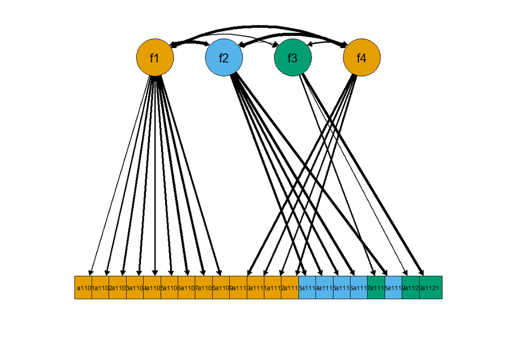

**Standardized Loading Across Folds**

| variable | mean | range | loading flag | heywood flag |
| --- | --- | --- | --- | --- |
| a1101x | 0.24 | 0.21 - 0.31 | 9 | 0 |
| a1102x | 0.57 | 0.48 - 0.63 | 0 | 0 |
| a1103x | 0.75 | 0.69 - 0.81 | 0 | 0 |
| a1104x | 0.53 | 0.47 - 0.59 | 0 | 0 |
| a1105x | 0.51 | 0.46 - 0.60 | 0 | 0 |
| a1106x | 0.62 | 0.58 - 0.68 | 0 | 0 |
| a1107x | 0.83 | 0.79 - 0.90 | 0 | 0 |
| a1108x | 0.70 | 0.64 - 0.76 | 0 | 0 |
| a1109x | 0.63 | 0.57 - 0.69 | 0 | 0 |
| a1110x | 0.92 | 0.83 - 0.98 | 0 | 0 |
| a1111x | 0.75 | 0.65 - 0.86 | 0 | 0 |
| a1112x | 0.69 | 0.61 - 0.78 | 0 | 0 |
| a1113x | 0.73 | 0.67 - 0.81 | 0 | 0 |
| a1114x | 0.76 | 0.70 - 0.82 | 0 | 0 |
| a1115x | 1.02 | 0.91 - 1.12 | 0 | 0 |
| a1116x | 0.97 | 0.92 - 1.06 | 0 | 0 |
| a1117x | 1.06 | 0.99 - 1.13 | 0 | 0 |
| a1118x | 0.67 | 0.53 - 0.80 | 0 | 0 |
| a1119x | 0.95 | 0.86 - 1.01 | 0 | 0 |
| a1120x | 0.69 | 0.49 - 0.86 | 0 | 0 |
| a1121x | 0.95 | 0.76 - 1.05 | 0 | 0 |

Note: loadings flagged when < 0.3 in a fold. ‘heywood flag’ is the number of folds the variable’s estimated residual variance was negative

**Mean Factor Correlations**

|  | f1 | f2 | f3 | f4 | flag |
| --- | --- | --- | --- | --- | --- |
| f1 | 1.00 |  |  |  | 1 |
| f2 | 0.88 | 1.00 |  |  | 2 |
| f3 | 0.44 | 0.42 | 1.00 |  | 0 |
| f4 | 0.79 | 0.85 | 0.48 | 1.00 | 1 |

Note: ‘flag’ is the number of folds the factor had a correlation > 0.9

**Scale Reliability Across Folds**

| factor | omega_h mean | omega_h range | omega_h flag | alpha mean | alpha range | alpha flag |
| --- | --- | --- | --- | --- | --- | --- |
| f1 | 0.81 | 0.78 - 0.83 | 0 | 0.80 | 0.78 - 0.83 | 0 |
| f2 | 0.85 | 0.83 - 0.87 | 0 | 0.85 | 0.83 - 0.86 | 0 |
| f3 | 0.60 | 0.54 - 0.65 | 4 | 0.62 | 0.58 - 0.66 | 4 |
| f4 | 0.68 | 0.64 - 0.71 | 0 | 0.69 | 0.64 - 0.71 | 0 |

Note: ‘flag’ is the number of folds the scale had a reliability < 0.6

## 5-factor

**Factor Structure**

f1 =~ a1101x + a1102x + a1103x + a1104x + a1105x + a1106x + a1107x + a1108x + a1109x

f2 =~ a1115x + a1116x

f3 =~ a1118x + a1120x + a1121x

f4 =~ a1114x + a1117x + a1119x

f5 =~ a1110x + a1111x + a1112x + a1113x

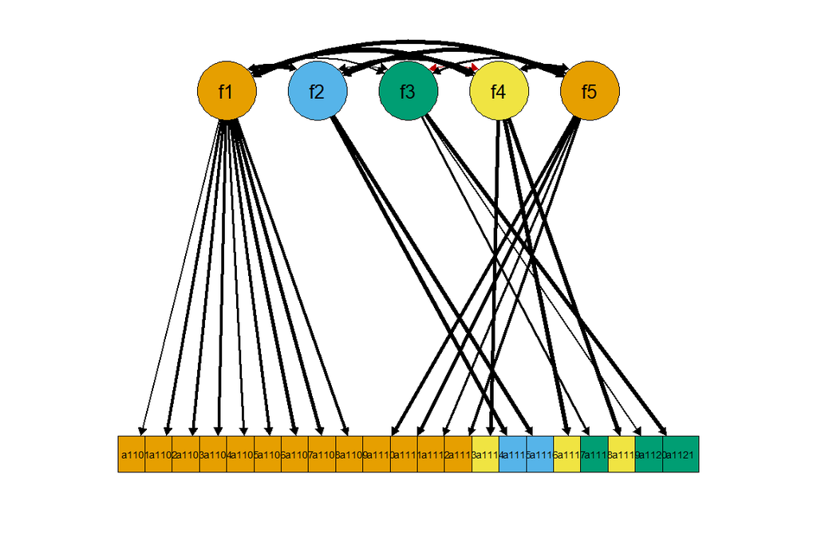

**Standardized Loading Across Folds**

| variable | mean | range | loading flag | heywood flag |
| --- | --- | --- | --- | --- |
| a1101x | 0.24 | 0.21 - 0.31 | 9 | 0 |
| a1102x | 0.57 | 0.48 - 0.63 | 0 | 0 |
| a1103x | 0.75 | 0.68 - 0.81 | 0 | 0 |
| a1104x | 0.53 | 0.47 - 0.59 | 0 | 0 |
| a1105x | 0.52 | 0.46 - 0.61 | 0 | 0 |
| a1106x | 0.62 | 0.57 - 0.68 | 0 | 0 |
| a1107x | 0.83 | 0.80 - 0.90 | 0 | 0 |
| a1108x | 0.70 | 0.64 - 0.76 | 0 | 0 |
| a1109x | 0.63 | 0.57 - 0.69 | 0 | 0 |
| a1110x | 0.92 | 0.83 - 0.98 | 0 | 0 |
| a1111x | 0.75 | 0.65 - 0.86 | 0 | 0 |
| a1112x | 0.70 | 0.61 - 0.78 | 0 | 0 |
| a1113x | 0.74 | 0.67 - 0.81 | 0 | 0 |
| a1114x | 0.79 | 0.72 - 0.84 | 0 | 0 |
| a1115x | 1.08 | 0.96 - 1.22 | 0 | 0 |
| a1116x | 1.03 | 0.98 - 1.12 | 0 | 0 |
| a1117x | 1.09 | 1.03 - 1.15 | 0 | 0 |
| a1118x | 0.67 | 0.54 - 0.81 | 0 | 0 |
| a1119x | 0.98 | 0.89 - 1.03 | 0 | 0 |
| a1120x | 0.69 | 0.51 - 0.85 | 0 | 0 |
| a1121x | 0.93 | 0.74 - 1.01 | 0 | 0 |

Note: loadings flagged when < 0.3 in a fold. ‘heywood flag’ is the number of folds the variable’s estimated residual variance was negative

**Mean Factor Correlations**

|  | f1 | f2 | f3 | f4 | f5 | flag |
| --- | --- | --- | --- | --- | --- | --- |
| f1 | 1.00 |  |  |  |  | 0 |
| f2 | 0.83 | 1.00 |  |  |  | 1 |
| f3 | 0.44 | 0.43 | 1.00 |  |  | 0 |
| f4 | 0.85 | 0.86 | 0.39 | 1.00 |  | 1 |
| f5 | 0.79 | 0.78 | 0.49 | 0.83 | 1.00 | 0 |

Note: ‘flag’ is the number of folds the factor had a correlation > 0.9

**Scale Reliability Across Folds**

| factor | omega_h mean | omega_h range | omega_h flag | alpha mean | alpha range | alpha flag |
| --- | --- | --- | --- | --- | --- | --- |
| f1 | 0.81 | 0.78 - 0.83 | 0 | 0.80 | 0.78 - 0.83 | 0 |
| f2 | 0.73 | 0.67 - 0.78 | 0 | 0.73 | 0.67 - 0.77 | 0 |
| f3 | 0.59 | 0.54 - 0.64 | 6 | 0.62 | 0.58 - 0.66 | 4 |
| f4 | 0.82 | 0.80 - 0.85 | 0 | 0.81 | 0.80 - 0.84 | 0 |
| f5 | 0.68 | 0.65 - 0.71 | 0 | 0.69 | 0.64 - 0.71 | 0 |

Note: ‘flag’ is the number of folds the scale had a reliability < 0.6

## Custom 2f

**Factor Structure**

f1 =~ a1101x + a1102x + a1103x + a1104x + a1105x + a1106x + a1107x + a1108x + a1109x + a1110x

f2 =~ a1111x + a1112x + a1113x + a1114x + a1115x + a1116x + a1117x + a1118x + a1119x + a1120x + a1121x

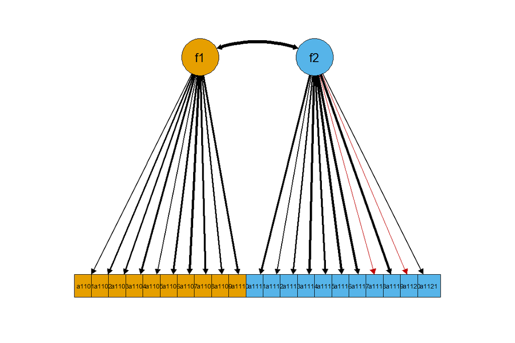

**Standardized Loading Across Folds**

| variable | mean | range | loading flag | heywood flag |
| --- | --- | --- | --- | --- |
| a1101x | 0.23 | 0.20 - 0.31 | 9 | 0 |
| a1102x | 0.56 | 0.46 - 0.62 | 0 | 0 |
| a1103x | 0.74 | 0.67 - 0.80 | 0 | 0 |
| a1104x | 0.52 | 0.45 - 0.57 | 0 | 0 |
| a1105x | 0.51 | 0.46 - 0.60 | 0 | 0 |
| a1106x | 0.61 | 0.56 - 0.66 | 0 | 0 |
| a1107x | 0.81 | 0.78 - 0.88 | 0 | 0 |
| a1108x | 0.68 | 0.63 - 0.74 | 0 | 0 |
| a1109x | 0.61 | 0.55 - 0.67 | 0 | 0 |
| a1110x | 0.84 | 0.72 - 0.91 | 0 | 0 |
| a1111x | 0.69 | 0.57 - 0.77 | 0 | 0 |
| a1112x | 0.63 | 0.55 - 0.72 | 0 | 0 |
| a1113x | 0.67 | 0.59 - 0.73 | 0 | 0 |
| a1114x | 0.74 | 0.67 - 0.79 | 0 | 0 |
| a1115x | 0.99 | 0.90 - 1.10 | 0 | 0 |
| a1116x | 0.95 | 0.89 - 1.04 | 0 | 0 |
| a1117x | 1.03 | 0.97 - 1.11 | 0 | 0 |
| a1118x | 0.33 | 0.22 - 0.44 | 4 | 0 |
| a1119x | 0.93 | 0.84 - 0.99 | 0 | 0 |
| a1120x | 0.34 | 0.17 - 0.39 | 2 | 0 |
| a1121x | 0.50 | 0.37 - 0.60 | 0 | 0 |

Note: loadings flagged when < 0.3 in a fold. ‘heywood flag’ is the number of folds the variable’s estimated residual variance was negative

**Mean Factor Correlations**

|  | f1 | f2 | flag |
| --- | --- | --- | --- |
| f1 | 1.00 |  | 8 |
| f2 | 0.91 | 1.00 | 8 |

Note: ‘flag’ is the number of folds the factor had a correlation > 0.9

**Scale Reliability Across Folds**

| factor | omega_h mean | omega_h range | omega_h flag | alpha mean | alpha range | alpha flag |
| --- | --- | --- | --- | --- | --- | --- |
| f1 | 0.81 | 0.79 - 0.83 | 0 | 0.82 | 0.80 - 0.83 | 0 |
| f2 | 0.81 | 0.79 - 0.82 | 0 | 0.83 | 0.81 - 0.84 | 0 |

Note: ‘flag’ is the number of folds the scale had a reliability < 0.6

## Break

**Factor Structure**

f1 =~ a1101x + a1102x

f2 =~ a1103x + a1104x

f3 =~ a1105x + a1106x

f4 =~ a1107x + a1108x

f5 =~ a1109x + a1110x

f6 =~ a1111x + a1112x

f7 =~ a1113x + a1114x + a1115x + a1116x + a1117x + a1118x + a1119x + a1120x + a1121x

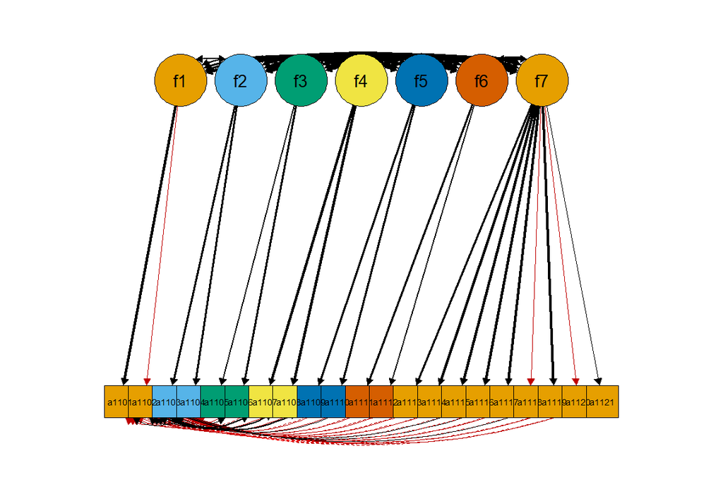

**Standardized Loading Across Folds**

| variable | mean | range | loading flag | heywood flag |
| --- | --- | --- | --- | --- |
| a1101x | 0.39 | 0.35 - 0.43 | 0 | 0 |
| a1102x | 0.29 | 0.18 - 0.35 | 5 | 0 |
| a1103x | 0.77 | 0.68 - 0.83 | 0 | 0 |
| a1104x | 0.54 | 0.47 - 0.58 | 0 | 0 |
| a1105x | 0.53 | 0.43 - 0.65 | 0 | 0 |
| a1106x | 0.62 | 0.55 - 0.72 | 0 | 0 |
| a1107x | 0.88 | 0.81 - 0.93 | 0 | 0 |
| a1108x | 0.75 | 0.67 - 0.82 | 0 | 0 |
| a1109x | 0.56 | 0.45 - 0.62 | 0 | 0 |
| a1110x | 0.80 | 0.72 - 0.91 | 0 | 0 |
| a1111x | 0.76 | 0.66 - 0.91 | 0 | 0 |
| a1112x | 0.69 | 0.60 - 0.77 | 0 | 0 |
| a1113x | 0.67 | 0.59 - 0.73 | 0 | 0 |
| a1114x | 0.74 | 0.67 - 0.80 | 0 | 0 |
| a1115x | 0.99 | 0.90 - 1.10 | 0 | 0 |
| a1116x | 0.95 | 0.88 - 1.05 | 0 | 0 |
| a1117x | 1.03 | 0.96 - 1.11 | 0 | 0 |
| a1118x | 0.33 | 0.21 - 0.44 | 4 | 0 |
| a1119x | 0.93 | 0.85 - 0.99 | 0 | 0 |
| a1120x | 0.34 | 0.17 - 0.40 | 2 | 0 |
| a1121x | 0.51 | 0.37 - 0.60 | 0 | 0 |

Note: loadings flagged when < 0.3 in a fold. ‘heywood flag’ is the number of folds the variable’s estimated residual variance was negative

**Mean Factor Correlations**

|  | f1 | f2 | f3 | f4 | f5 | f6 | f7 | flag |
| --- | --- | --- | --- | --- | --- | --- | --- | --- |
| f1 | 1.00 |  |  |  |  |  |  | 0 |
| f2 | 0.50 | 1.00 |  |  |  |  |  | 10 |
| f3 | 0.45 | 1.04 | 1.00 |  |  |  |  | 10 |
| f4 | 0.49 | 0.89 | 0.89 | 1.00 |  |  |  | 8 |
| f5 | 0.54 | 0.97 | 0.96 | 0.92 | 1.00 |  |  | 10 |
| f6 | 0.37 | 0.74 | 0.83 | 0.72 | 1.02 | 1.00 |  | 10 |
| f7 | 0.69 | 0.87 | 0.88 | 0.84 | 1.02 | 0.90 | 1.00 | 10 |

Note: ‘flag’ is the number of folds the factor had a correlation > 0.9

**Scale Reliability Across Folds**

| factor | omega_h mean | omega_h range | omega_h flag | alpha mean | alpha range | alpha flag |
| --- | --- | --- | --- | --- | --- | --- |
| f1 | 0.25 | 0.16 - 0.30 | 10 | 0.34 | 0.27 - 0.39 | 10 |
| f2 | 0.54 | 0.45 - 0.60 | 10 | 0.52 | 0.43 - 0.57 | 10 |
| f3 | 0.41 | 0.34 - 0.48 | 10 | 0.41 | 0.34 - 0.48 | 10 |
| f4 | 0.71 | 0.65 - 0.78 | 0 | 0.71 | 0.64 - 0.78 | 0 |
| f5 | 0.44 | 0.36 - 0.52 | 10 | 0.43 | 0.34 - 0.50 | 10 |
| f6 | 0.46 | 0.41 - 0.52 | 10 | 0.46 | 0.41 - 0.51 | 10 |
| f7 | 0.79 | 0.76 - 0.80 | 0 | 0.81 | 0.78 - 0.82 | 0 |

Note: ‘flag’ is the number of folds the scale had a reliability < 0.6

# Appendix

## Within Fold Model Fit

| fold | 1-factor df | 1-factor chisq | 1-factor cfi | 1-factor rmsea | 2-factor df | 2-factor chisq | 2-factor cfi | 2-factor rmsea | 4-factor df | 4-factor chisq | 4-factor cfi | 4-factor rmsea | 5-factor df | 5-factor chisq | 5-factor cfi | 5-factor rmsea |
| --- | --- | --- | --- | --- | --- | --- | --- | --- | --- | --- | --- | --- | --- | --- | --- | --- |
| 1 | 189.00 | 337.08 | 0.98 | 0.03 | 188.00 | 263.17 | 0.99 | 0.02 | 183.00 | 178.22 | 1.00 | 0.00 | 179.00 | 177.37 | 1.00 | 0.00 |
| 2 | 189.00 | 343.66 | 0.98 | 0.03 | 188.00 | 233.75 | 0.99 | 0.02 | 183.00 | 151.29 | 1.00 | 0.00 | 179.00 | 152.52 | 1.00 | 0.00 |
| 3 | 189.00 | 325.45 | 0.99 | 0.03 | 188.00 | 216.88 | 1.00 | 0.01 | 183.00 | 156.13 | 1.00 | 0.00 | 179.00 | 159.07 | 1.00 | 0.00 |
| 4 | 189.00 | 355.26 | 0.98 | 0.03 | 188.00 | 230.94 | 1.00 | 0.02 | 183.00 | 173.57 | 1.00 | 0.00 | 179.00 | 154.22 | 1.00 | 0.00 |
| 5 | 189.00 | 338.88 | 0.99 | 0.03 | 188.00 | 202.91 | 1.00 | 0.01 | 183.00 | 142.37 | 1.00 | 0.00 | 179.00 | 138.00 | 1.00 | 0.00 |
| 6 | 189.00 | 318.90 | 0.98 | 0.03 | 188.00 | 205.14 | 1.00 | 0.01 | 183.00 | 143.58 | 1.00 | 0.00 | 179.00 | 134.58 | 1.00 | 0.00 |
| 7 | 189.00 | 348.09 | 0.98 | 0.03 | 188.00 | 272.44 | 0.99 | 0.02 | 183.00 | 188.24 | 1.00 | 0.01 | 179.00 | 198.25 | 1.00 | 0.01 |
| 8 | 189.00 | 365.06 | 0.98 | 0.03 | 188.00 | 294.41 | 0.99 | 0.03 | 183.00 | 207.22 | 1.00 | 0.01 | 179.00 | 217.11 | 1.00 | 0.02 |
| 9 | 189.00 | 315.71 | 0.99 | 0.03 | 188.00 | 226.04 | 1.00 | 0.02 | 183.00 | 142.32 | 1.00 | 0.00 | 179.00 | 135.19 | 1.00 | 0.00 |
| 10 | 189.00 | 271.31 | 0.99 | 0.02 | 188.00 | 190.71 | 1.00 | 0.00 | 183.00 | 134.71 | 1.00 | 0.00 | 179.00 | 139.52 | 1.00 | 0.00 |
| Mean | 189.00 | 331.94 | 0.98 | 0.03 | 188.00 | 233.64 | 1.00 | 0.02 | 183.00 | 161.76 | 1.00 | 0.00 | 179.00 | 160.58 | 1.00 | 0.00 |

| fold | Custom 2f df | Custom 2f chisq | Custom 2f cfi | Custom 2f rmsea | Break df | Break chisq | Break cfi | Break rmsea |
| --- | --- | --- | --- | --- | --- | --- | --- | --- |
| 1 | 188.00 | 323.42 | 0.98 | 0.03 | 129.00 | 283.89 | 0.98 | 0.04 |
| 2 | 188.00 | 327.44 | 0.98 | 0.03 | 129.00 | 276.48 | 0.98 | 0.04 |
| 3 | 188.00 | 295.66 | 0.99 | 0.03 | 129.00 | 247.97 | 0.99 | 0.03 |
| 4 | 188.00 | 335.49 | 0.99 | 0.03 | 129.00 | 270.78 | 0.99 | 0.04 |
| 5 | 188.00 | 323.36 | 0.99 | 0.03 | 129.00 | 265.90 | 0.99 | 0.04 |
| 6 | 188.00 | 293.84 | 0.99 | 0.03 | 129.00 | 236.78 | 0.99 | 0.03 |
| 7 | 188.00 | 334.74 | 0.98 | 0.03 | 129.00 | 275.87 | 0.98 | 0.04 |
| 8 | 188.00 | 352.03 | 0.98 | 0.03 | 129.00 | 301.01 | 0.98 | 0.04 |
| 9 | 188.00 | 299.61 | 0.99 | 0.03 | 129.00 | 248.03 | 0.99 | 0.03 |
| 10 | 188.00 | 256.91 | 0.99 | 0.02 | 129.00 | 210.15 | 0.99 | 0.03 |
| Mean | 188.00 | 314.25 | 0.99 | 0.03 | 129.00 | 261.69 | 0.99 | 0.04 |

## All EFA Structures

### Factors: 1

**Factor Structure Option 1**

**In Folds: 1, 2, 3, 4, 5, 6, 7, 8, 9, 10**

f1 =~ a1101x + a1102x + a1103x + a1104x + a1105x + a1106x + a1107x + a1108x + a1109x + a1110x + a1111x + a1112x + a1113x + a1114x + a1115x + a1116x + a1117x + a1118x + a1119x + a1120x + a1121x

### Factors: 2

**Factor Structure Option 1**

**In Folds: 1, 2, 3, 4, 5, 6, 7, 8, 9, 10**

f1 =~ a1101x + a1102x + a1103x + a1104x + a1105x + a1106x + a1107x + a1108x + a1109x + a1110x + a1111x + a1112x + a1113x + a1114x + a1115x + a1116x + a1117x + a1119x

f2 =~ a1118x + a1120x + a1121x

### Factors: 3

**Factor Structure Option 1**

**In Folds: 1, 2, 3, 4, 5, 6, 7, 8, 9, 10**

Structure contained single item factor

### Factors: 4

**Factor Structure Option 1**

**In Folds: 1, 3, 4, 5, 7, 8, 10**

f1 =~ a1101x + a1102x + a1103x + a1104x + a1105x + a1106x + a1107x + a1108x + a1109x

f2 =~ a1114x + a1115x + a1116x + a1117x + a1119x

f3 =~ a1118x + a1120x + a1121x

f4 =~ a1110x + a1111x + a1112x + a1113x

**Factor Structure Option 2**

**In Folds: 2**

f1 =~ a1101x + a1102x + a1103x + a1104x + a1105x + a1106x + a1107x + a1108x + a1109x + a1114x

f2 =~ a1115x + a1116x + a1117x + a1119x

f3 =~ a1118x + a1120x + a1121x

f4 =~ a1110x + a1111x + a1112x + a1113x

**Factor Structure Option 3**

**In Folds: 6**

f1 =~ a1101x + a1102x + a1103x + a1104x + a1105x + a1106x + a1107x + a1108x + a1109x + a1114x

f2 =~ a1115x + a1116x + a1119x

f3 =~ a1118x + a1120x + a1121x

f4 =~ a1110x + a1111x + a1112x + a1113x + a1117x

**Factor Structure Option 4**

**In Folds: 9**

f1 =~ a1101x + a1102x + a1103x + a1104x + a1105x + a1106x + a1107x + a1108x + a1109x + a1114x

f2 =~ a1115x + a1116x

f3 =~ a1118x + a1120x + a1121x

f4 =~ a1110x + a1111x + a1112x + a1113x + a1117x + a1119x

### Factors: 5

**Factor Structure Option 1**

**In Folds: 1, 2, 3, 4, 5, 6, 7, 8, 9, 10**

f1 =~ a1101x + a1102x + a1103x + a1104x + a1105x + a1106x + a1107x + a1108x + a1109x

f2 =~ a1115x + a1116x

f3 =~ a1118x + a1120x + a1121x

f4 =~ a1114x + a1117x + a1119x

f5 =~ a1110x + a1111x + a1112x + a1113x